# CMPINF 2100: Midterm exam

## Problem 05

You must cluster the rows of dfb using the 4 operational variables `x1` through `x4`. You must decide how many clusters to use and describe how you made that choice. You may use KMeans OR Hierarchical clustering. Include any figures that helped you make that choice.

Visualize your cluster analysis results by:

- Plotting the number of observations per cluster.
- Visualizing the relationships between the operational variables GIVEN the cluster.

You are interested in the PROPORTION of cell phone cases that failed the DROP TEST. Are any of the clusters associated with higher failure PROPORTIONS than others? Based on your visualizations how would you describe that cluster?

#### Solution

Since we are interested in the PROPORTION of cell phone cases that failed the DROP TEST, we will filter rows where `Result` is not missing (NaN).

```python
dfb_filtered = dfb[dfb['Result'].notna()].copy()
dfb_filtered
```

|  | ID | Batch | s_id | x1 | x2 | x3 | x4 | machine_id | Supplier | Density | test_group_id | Result |
| --- | --- | --- | --- | --- | --- | --- | --- | --- | --- | --- | --- | --- |
| 1 | B001-M01-S002 | 1 | 2 | 46.887333 | 112.266102 | 23.197330 | 13.064709 | machine_01 | B | 10.388587 | A-0 | 1.0 |
| 23 | B001-M01-S024 | 1 | 24 | 51.531574 | 100.207219 | 22.281345 | 13.796810 | machine_01 | B | 10.388587 | A-0 | 1.0 |
| 29 | B001-M01-S030 | 1 | 30 | 48.306819 | 109.445722 | 22.910858 | 13.839830 | machine_01 | B | 10.388587 | A-0 | 0.0 |
| 37 | B001-M01-S038 | 1 | 38 | 52.058573 | 93.272568 | 21.937216 | 13.332882 | machine_01 | B | 10.388587 | A-0 | 1.0 |
| 47 | B001-M01-S048 | 1 | 48 | 50.564504 | 109.184587 | 22.083064 | 13.954942 | machine_01 | B | 10.388587 | A-0 | 1.0 |
| ... | ... | ... | ... | ... | ... | ... | ... | ... | ... | ... | ... | ... |
| 14675 | B049-M03-S051 | 49 | 51 | 49.885679 | 104.690007 | 22.055338 | 13.882302 | machine_03 | A | 9.111256 | K-5 | 1.0 |
| 14685 | B049-M03-S061 | 49 | 61 | 49.716703 | 104.346466 | 22.059022 | 13.543388 | machine_03 | A | 9.111256 | K-5 | 1.0 |
| 14688 | B049-M03-S064 | 49 | 64 | 49.406329 | 103.557885 | 21.999548 | 13.759379 | machine_03 | A | 9.111256 | K-5 | 1.0 |
| 14710 | B049-M03-S086 | 49 | 86 | 50.582042 | 107.106557 | 21.958052 | 13.686061 | machine_03 | A | 9.111256 | K-5 | 1.0 |
| 14721 | B049-M03-S097 | 49 | 97 | 49.665081 | 106.966772 | 22.137368 | 13.500124 | machine_03 | A | 9.111256 | K-5 | 1.0 |

1412 rows × 12 columns

```python
dfb_filt_op_var = dfb_filtered[['x1', 'x2', 'x3', 'x4']].copy()
```

```python
dfb_filt_op_var.melt(ignore_index=False)
```

|  | variable | value |
| --- | --- | --- |
| 1 | x1 | 46.887333 |
| 23 | x1 | 51.531574 |
| 29 | x1 | 48.306819 |
| 37 | x1 | 52.058573 |
| 47 | x1 | 50.564504 |
| ... | ... | ... |
| 14675 | x4 | 13.882302 |
| 14685 | x4 | 13.543388 |
| 14688 | x4 | 13.759379 |
| 14710 | x4 | 13.686061 |
| 14721 | x4 | 13.500124 |

5648 rows × 2 columns

#### Preprocess

Since the magnitud and scale is dominated by one variable we must STANDARDIZE.

```python
dfbx_filt = StandardScaler().fit_transform( dfb_filt_op_var )
```

```python
dfbx_filt.shape
```

```
(1412, 4)
```

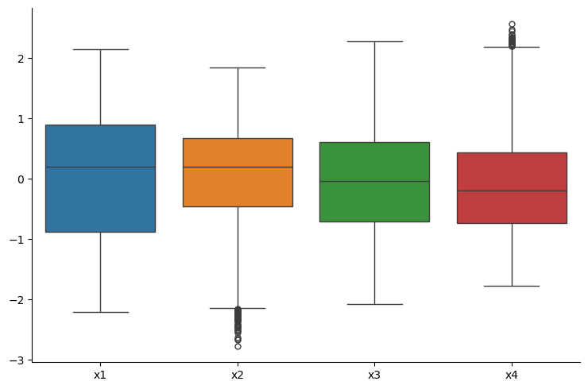

```python
sns.catplot( data = pd.DataFrame( dfbx_filt, columns = dfb_filt_op_var.columns), kind='box', aspect=1.5)

plt.show()
```

## Finding Optimal number of clusters

```python
tots_within = []

K = range(1,31)

for k in K:
    km = KMeans(n_clusters=k, random_state=121, n_init=25, max_iter=500)
    km = km.fit(dfbx_filt)
    tots_within.append( km.inertia_ )
```

[output not shown]

[output cut: 17 more lines]

[output not shown]

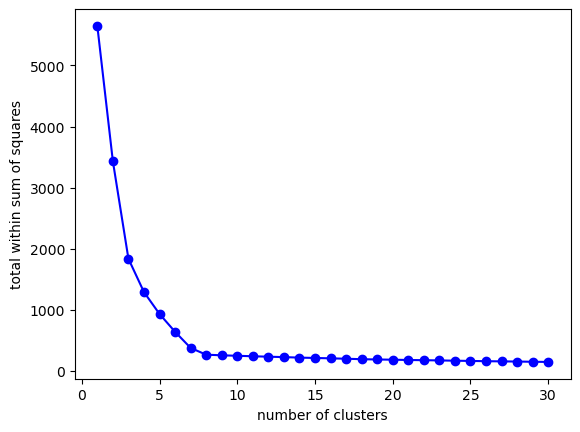

```python
fig, ax = plt.subplots()

ax.plot( K, tots_within, 'bo-')
ax.set_xlabel('number of clusters')
ax.set_ylabel('total within sum of squares')

plt.show()
```

Since we are clustering the 4 operating variables, we will use 3 clusters because our dataset contains 3 machines that operate based on these variables.

```python
clusters_3 = KMeans(n_clusters=3, random_state=121, n_init=25, max_iter=500).fit_predict(dfbx_filt)
```

```python
dfb_filtered['k3'] = pd.Series( clusters_3, index=dfb_filtered.index).astype('category')
```

```python
dfb_filtered.info()
```

```
<class 'pandas.core.frame.DataFrame'>
Index: 1412 entries, 1 to 14721
Data columns (total 13 columns):
 #   Column         Non-Null Count  Dtype
---  ------         --------------  -----
 0   ID             1412 non-null   object
 1   Batch          1412 non-null   category
 2   s_id           1412 non-null   int64
 3   x1             1412 non-null   float64
 4   x2             1412 non-null   float64
 5   x3             1412 non-null   float64
 6   x4             1412 non-null   float64
 7   machine_id     1412 non-null   object
 8   Supplier       1412 non-null   object
 9   Density        1412 non-null   float64
 10  test_group_id  1412 non-null   object
 11  Result         1412 non-null   float64
 12  k3             1412 non-null   category
dtypes: category(2), float64(6), int64(1), object(4)
memory usage: 137.7+ KB
```

```python
dfb_filtered.k3.value_counts()
```

```
k3
0    666
1    572
2    174
Name: count, dtype: int64
```

Plotting the number of observations per cluster.

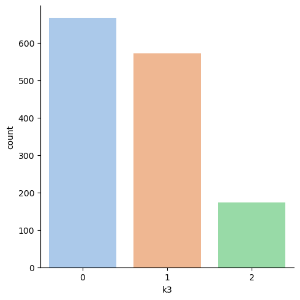

```python
sns.catplot( data = dfb_filtered.loc[:,['x1', 'x2', 'x3', 'x4', 'k3']], x='k3', kind='count', palette='pastel')

plt.show()
```

Visualizing the relationships between the operational variables GIVEN the cluster.

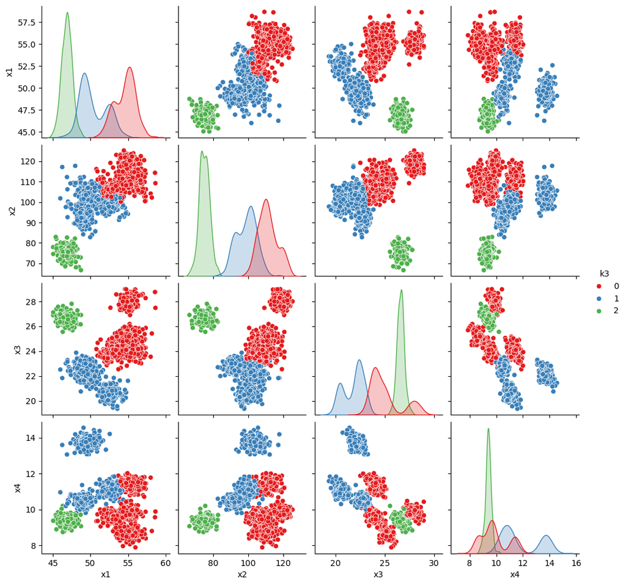

```python
sns.pairplot( data = dfb_filtered.loc[:,['x1', 'x2', 'x3', 'x4', 'k3']], hue='k3',
             diag_kws={'common_norm':False}, palette='Set1')

plt.show()
```

Are any of the clusters associated with higher failure PROPORTIONS than others?

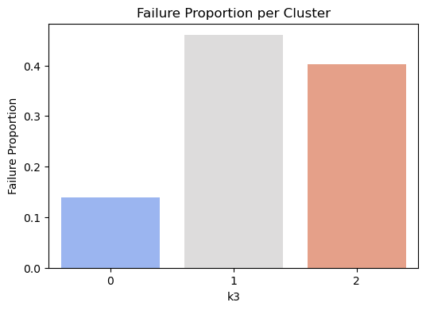

```python
# Calculate failure proportion per cluster
failure_proportion_dfb = dfb_filtered.groupby('k3')['Result'].mean().reset_index()

# Plot failure proportions by cluster
plt.figure(figsize=(6, 4))
sns.barplot(data=failure_proportion_dfb, x='k3', y='Result', palette='coolwarm')
plt.xlabel("k3")
plt.ylabel("Failure Proportion")
plt.title("Failure Proportion per Cluster")
plt.show()
```

Based on your visualizations how would you describe that cluster?

```python
failure_proportion_by_cluster = dfb_filtered.groupby('k3')['Result'].mean().reset_index()
failure_proportion_by_cluster.columns = ['Cluster', 'Failure_Proportion']

# Show the failure proportions
print(failure_proportion_by_cluster)
```

```
  Cluster  Failure_Proportion
0       0            0.139640
1       1            0.459790
2       2            0.402299
```

Based on the results of the clustering analysis:

Cluster Failure Proportions:

- Cluster 0 has a failure proportion of 0.14, which is the lowest among the clusters.
- Cluster 1 has a failure proportion of 0.46, which is much higher than Cluster 0.
- Cluster 2 has a failure proportion of 0.40, also higher than Cluster 0.

From this, we can conclude that Clusters 1 and 2 are associated with higher failure rates (larger proportion of failures in the drop test), while Cluster 0 has a relatively lower failure rate.

Additional Observations:

- Cluster 0 has more values than Cluster 1 and Cluster 2, meaning that even though its failure proportion is lower, it might still represent a large portion of the overall data. This could suggest that Cluster 0 represents a more stable or common set of conditions where cases pass the test more often.
- Cluster 1 and Cluster 2 might represent problematic conditions or scenarios where cell phone cases tend to fail the test more frequently.